# Projeto da Disciplina: Fundamentos de Machine Learning com Scikit-Learn

**Aluna:** Ingrid Ornellas Coda Sant'Anna Gomes

##### **Repositório do Projeto:** [GitHub](https://github.com/ingridcoda/mit-ia-ml/)

## 1. O Problema de Negócio e os Dados

### O Desafio

Instituições financeiras lidam diariamente com o desafio de separar bons de maus pagadores antes de conceder crédito. Errar nessa decisão custa caro. Abordagens antigas, baseadas em regras fixas, já não dão conta de analisar a complexidade do comportamento humano. É aqui que o Machine Learning entra: precisamos de modelos capazes de entender padrões ocultos no histórico do cliente para prever se ele vai ou não pagar a próxima fatura.

### Nossa Base de Dados

```python
# Configuração inicial e verificação de dependências
import os
import sys

if os.path.exists('requirements.txt'):
    !{sys.executable} -m pip install --upgrade pip -q && pip install -r requirements.txt -q
    print("Bibliotecas de ambiente prontas.")
```

```
Bibliotecas de ambiente prontas.
```

```python
# Importação das Bibliotecas
import pandas as pd
import numpy as np
import matplotlib.pyplot as plt
import seaborn as sns

from sklearn.model_selection import train_test_split, GridSearchCV
from sklearn.preprocessing import StandardScaler
from sklearn.metrics import (
    classification_report,
    accuracy_score,
    precision_score,
    recall_score,
    f1_score,
    ConfusionMatrixDisplay
)
from sklearn.linear_model import Perceptron
from sklearn.tree import DecisionTreeClassifier, plot_tree
from sklearn.ensemble import RandomForestClassifier

# Fixando sementes para garantir que os resultados sejam sempre os mesmos (reprodutibilidade)
RANDOM_STATE = 42
N_JOBS = -1
CV_FOLDS = 5

# Otimização visual para os gráficos
%config InlineBackend.figure_format = 'retina'
plt.style.use('seaborn-v0_8-whitegrid')

# Função auxiliar para não repetirmos código na hora de testar cada modelo
def avaliar_modelo(model, X_test, y_test, nome_modelo):
    y_pred = model.predict(X_test)
    print(f"=== Performance: {nome_modelo} ===")
    print(classification_report(y_test, y_pred))
    return {
        'Accuracy': accuracy_score(y_test, y_pred),
        'Precision': precision_score(y_test, y_pred),
        'Recall': recall_score(y_test, y_pred),
        'F1': f1_score(y_test, y_pred)
    }
```

## 2. Preparando o Terreno (Carga e Limpeza)

Vamos baixar os dados diretamente da fonte, limpar colunas inúteis (como o ID do cliente, que não ajuda a prever nada) e dar uma olhada em como as variáveis se relacionam.

```python
# Download e Carga dos Dados
import stat

DATA_DIR = 'data'
DATA_FILE = 'UCI_Credit_Card.csv'
DATA_PATH = os.path.join(DATA_DIR, DATA_FILE)
KAGGLE_FILE = 'kaggle.json'

# Garantindo permissão de leitura correta no arquivo do Kaggle
if os.path.exists(KAGGLE_FILE):
    os.chmod(KAGGLE_FILE, stat.S_IRUSR | stat.S_IWUSR)

if not os.path.exists(DATA_PATH):
    os.makedirs(DATA_DIR, exist_ok=True)
    os.environ['KAGGLE_CONFIG_DIR'] = os.getcwd()
    !kaggle datasets download -d uciml/default-of-credit-card-clients-dataset -p data --unzip --force > /dev/null 2>&1
    print("Dataset baixado com sucesso.")

try:
    df = pd.read_csv(DATA_PATH)
    # Padronizando o nome da nossa variável alvo
    df.rename(columns={'default.payment.next.month': 'target'}, inplace=True)

    # Jogando fora o ID para não causar vazamento de dados (Data Leakage)
    if 'ID' in df.columns:
        df.drop('ID', axis=1, inplace=True)

    print(f"Dados prontos: {df.shape[0]} linhas e {df.shape[1]} colunas.")
except FileNotFoundError:
    print(f"ERRO: Dataset não encontrado em {DATA_PATH}.")

# Separando quem avisa (Features/X) de quem queremos descobrir (Target/y)
X = df.drop('target', axis=1)
y = df['target']
```

```
Dataset baixado com sucesso.
Dados prontos: 30000 linhas e 24 colunas.
```

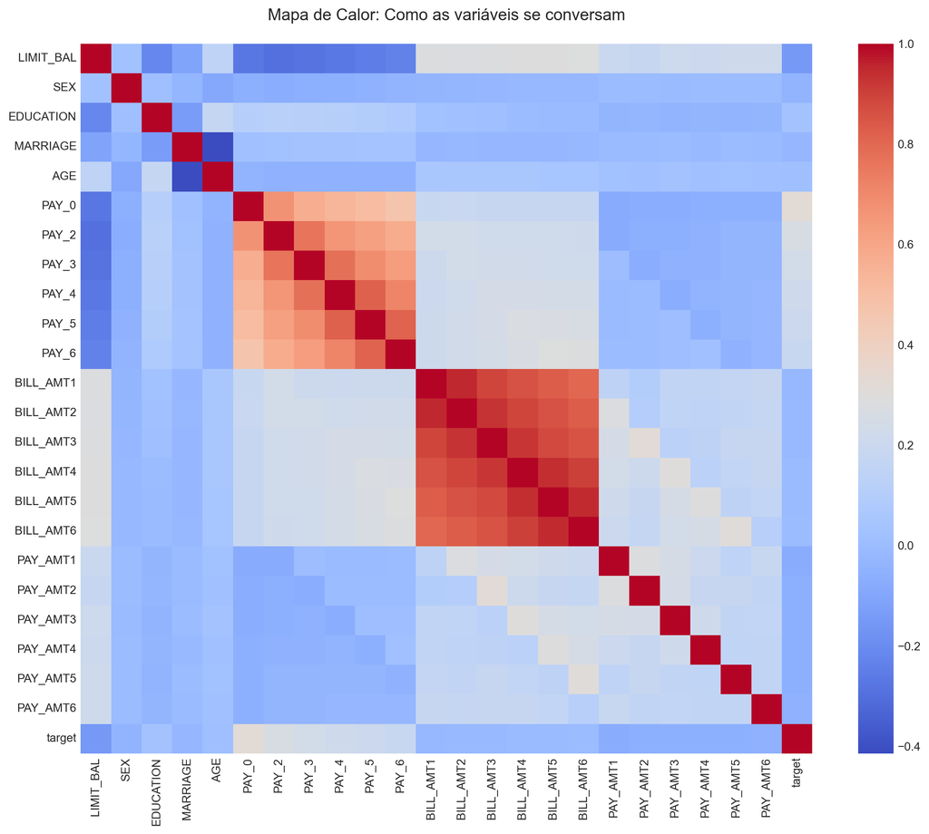

```python
# Olhando o Mapa de Correlação
# Repare como as variáveis PAY_0 e PAY_2 (que mostram se o cliente atrasou as últimas faturas)
# "acendem" na linha do nosso target. É o histórico falando alto.
plt.figure(figsize=(12, 10))
sns.heatmap(df.corr(numeric_only=True), cmap='coolwarm', annot=False)
plt.title("Mapa de Calor: Como as variáveis se conversam", pad=20, fontsize=14)
plt.tight_layout()
plt.show()
```

## 3. O Baseline: Começando de forma simples (Perceptron)

Antes de usar canhões, vamos usar um estilingue. O Perceptron é um modelo linear básico. A ideia aqui é responder à pergunta: *"Dá pra separar bons e maus pagadores simplesmente traçando uma linha reta nos dados?"*

**Ajuste técnico:** Dados reais de crédito são barulhentos. Se soltarmos o Perceptron puro aqui, ele vai ficar em loop infinito tentando achar uma separação perfeita que não existe. Para evitar isso (e os famosos warnings de não-convergência), ativamos o `early_stopping`. Basicamente, estamos dizendo ao modelo: *"Tente aprender, mas se você perceber que parou de evoluir, pode parar e entregar o que tem"*.

```python
# Separando dados de treino e teste (mantendo a proporção de calotes com o stratify)
X_train, X_test, y_train, y_test = train_test_split(
    X, y, test_size=0.3, random_state=RANDOM_STATE, stratify=y
)

# Modelos lineares precisam que os dados estejam na mesma escala (padronização)
scaler = StandardScaler()
X_train_scaled = scaler.fit_transform(X_train)
X_test_scaled = scaler.transform(X_test)

# Treinando o modelo Baseline
perc = Perceptron(
    early_stopping=True,
    validation_fraction=0.1,
    random_state=RANDOM_STATE
)
perc.fit(X_train_scaled, y_train)

# Guardando o resultado para compararmos depois
resultados_finais = {}
resultados_finais['Perceptron'] = avaliar_modelo(perc, X_test_scaled, y_test, "Perceptron (Linear)")
```

```
=== Performance: Perceptron (Linear) ===
              precision    recall  f1-score   support

           0       0.84      0.69      0.76      7009
           1       0.33      0.54      0.41      1991

    accuracy                           0.66      9000
   macro avg       0.59      0.61      0.58      9000
weighted avg       0.73      0.66      0.68      9000
```

### O que o Baseline nos ensina?

Olhando o relatório acima, o F1-Score para a classe 1 (Inadimplente) foi bem ruim. O modelo sofreu de *underfitting* (ficou simples demais para a tarefa). Isso responde nossa pergunta inicial: **não, não dá para separar risco de crédito com uma linha reta**. O comportamento financeiro é complexo.

```python
coefs = pd.DataFrame(perc.coef_.T, index=X.columns, columns=['Peso_Linear'])
print(f"Ponto de partida (Bias): {perc.intercept_[0]:.4f}\n")
print("Top 5 Variáveis que mais pesaram na decisão do Perceptron:")
print(coefs.abs().sort_values(by='Peso_Linear', ascending=False).head(5))
```

```
Ponto de partida (Bias): -6.0000

Top 5 Variáveis que mais pesaram na decisão do Perceptron:
           Peso_Linear
BILL_AMT5    10.672446
PAY_AMT1      7.842951
PAY_3         6.702427
PAY_4         6.609471
PAY_5         5.672654
```

## 4. Subindo o Nível: Árvore de Decisão

Já que uma linha reta não funciona, vamos usar uma Árvore de Decisão. Ela consegue fatiar os dados usando regras lógicas (se/então), lidando muito melhor com essa não-linearidade.

```python
# Testando uma Árvore sem limites de crescimento
dt_default = DecisionTreeClassifier(random_state=RANDOM_STATE)
dt_default.fit(X_train, y_train)

resultados_finais['DT Default'] = avaliar_modelo(dt_default, X_test, y_test, "Árvore (Sem Poda)")

print(f"\nProfundidade que a árvore atingiu: {dt_default.get_depth()}")
print(f"Quantas folhas (regras) ela criou: {dt_default.get_n_leaves()}")
```

```
=== Performance: Árvore (Sem Poda) ===
              precision    recall  f1-score   support

           0       0.83      0.81      0.82      7009
           1       0.38      0.40      0.39      1991

    accuracy                           0.72      9000
   macro avg       0.60      0.61      0.61      9000
weighted avg       0.73      0.72      0.73      9000


Profundidade que a árvore atingiu: 40
Quantas folhas (regras) ela criou: 3251
```

### O perigo de decorar os dados (Overfitting)

Veja a profundidade enorme que a árvore acima atingiu. Ela criou milhares de regrinhas minúsculas. O que aconteceu aqui foi um clássico *overfitting*: a árvore "decorou" os clientes de treino, mas vai falhar feio se vir um cliente novo.

Para resolver isso, vamos usar Validação Cruzada (`GridSearchCV`). Vamos testar várias combinações de "poda" (limitar a profundidade e o tamanho das folhas) e descobrir qual versão da árvore generaliza melhor, sem decorar nada.

```python
param_grid_dt = {
    'max_depth': [3, 5, 8, 10],
    'min_samples_leaf': [10, 20, 50],
    'class_weight': [None, 'balanced']
}

grid_dt = GridSearchCV(
    DecisionTreeClassifier(random_state=RANDOM_STATE),
    param_grid_dt,
    cv=CV_FOLDS,
    scoring='f1',
    n_jobs=N_JOBS
)
grid_dt.fit(X_train, y_train)

best_dt = grid_dt.best_estimator_
resultados_finais['DT Otimizada'] = avaliar_modelo(best_dt, X_test, y_test, "Árvore Otimizada")

print(f"\nA melhor combinação encontrada foi: {grid_dt.best_params_}")
```

```
=== Performance: Árvore Otimizada ===
              precision    recall  f1-score   support

           0       0.87      0.85      0.86      7009
           1       0.51      0.55      0.53      1991

    accuracy                           0.78      9000
   macro avg       0.69      0.70      0.69      9000
weighted avg       0.79      0.78      0.78      9000


A melhor combinação encontrada foi: {'class_weight': 'balanced', 'max_depth': 5, 'min_samples_leaf': 50}
```

### As Regras do Jogo

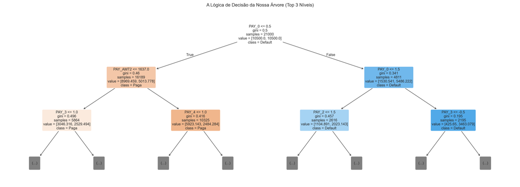

```python
plt.figure(figsize=(22, 8))
plot_tree(best_dt, feature_names=list(X.columns), class_names=['Paga', 'Default'], filled=True, max_depth=2, fontsize=11, rounded=True)
plt.title("A Lógica de Decisão da Nossa Árvore (Top 3 Níveis)", pad=20, fontsize=14)
plt.tight_layout()
plt.show()
```

## 5. O Peso Pesado: Random Forest (Ensemble)

Uma árvore é ótima porque é explicável, mas ela é um pouco instável. Se mudarmos um pouquinho os dados, a árvore muda inteira.

A solução? Plantar uma floresta. O **Random Forest** cria dezenas de árvores diferentes e tira a média das decisões delas. É um modelo muito mais robusto e assertivo. Assim como fizemos antes, vamos garantir a qualidade usando Validação Cruzada.

```python
param_grid_rf = {
    'n_estimators': [50, 100],
    'max_depth': [8, 12, 15],
    'min_samples_split': [5, 10],
    'class_weight': ['balanced'] # Aqui estamos dizendo ao modelo: "Preste muita atenção nos inadimplentes!"
}

print("Treinando nossa floresta e validando hiperparâmetros...")
grid_rf = GridSearchCV(
    RandomForestClassifier(random_state=RANDOM_STATE),
    param_grid_rf,
    cv=CV_FOLDS,
    scoring='f1',
    n_jobs=N_JOBS
)
grid_rf.fit(X_train, y_train)

best_rf = grid_rf.best_estimator_
resultados_finais['Random Forest'] = avaliar_modelo(best_rf, X_test, y_test, "Random Forest")
print(f"\nOs melhores parâmetros para a floresta foram: {grid_rf.best_params_}")
```

```
Treinando nossa floresta e validando hiperparâmetros...
=== Performance: Random Forest ===
              precision    recall  f1-score   support

           0       0.88      0.84      0.86      7009
           1       0.51      0.58      0.54      1991

    accuracy                           0.78      9000
   macro avg       0.69      0.71      0.70      9000
weighted avg       0.79      0.78      0.79      9000


Os melhores parâmetros para a floresta foram: {'class_weight': 'balanced', 'max_depth': 8, 'min_samples_split': 10, 'n_estimators': 50}
```

### O que mais importa?

Não podemos desenhar as dezenas de árvores da floresta, mas podemos perguntar a ela quais variáveis foram mais úteis para purificar as decisões. O gráfico abaixo mostra o "Top 10" do que realmente importa na hora de conceder crédito segundo o Random Forest.

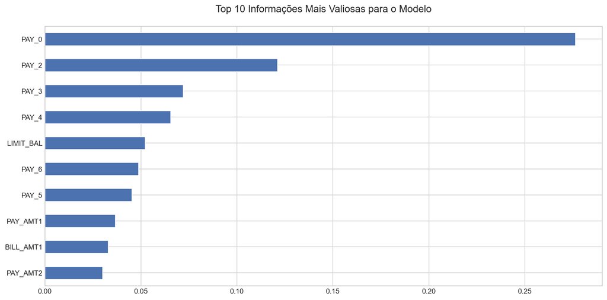

```python
importances = pd.Series(best_rf.feature_importances_, index=X.columns)
plt.figure(figsize=(12, 6))
importances.sort_values(ascending=True).tail(10).plot(kind='barh', color='#4c72b0')
plt.title("Top 10 Informações Mais Valiosas para o Modelo", pad=20, fontsize=14)
plt.tight_layout()
plt.show()
```

## 6. A Hora da Verdade: Comparação Final

Temos nossos modelos treinados e otimizados. Agora, vamos colocar as cartas na mesa e ver qual deles atende melhor às necessidades de um banco.

```
Tabela Consolidada de Resultados:
```

|  | Accuracy | Precision | Recall | F1 |
| --- | --- | --- | --- | --- |
| Perceptron | 0.656667 | 0.330767 | 0.539427 | 0.410080 |
| DT Default | 0.723222 | 0.381292 | 0.403315 | 0.391994 |
| DT Otimizada | 0.781889 | 0.506506 | 0.547464 | 0.526189 |
| Random Forest | 0.782667 | 0.507672 | 0.581617 | 0.542135 |

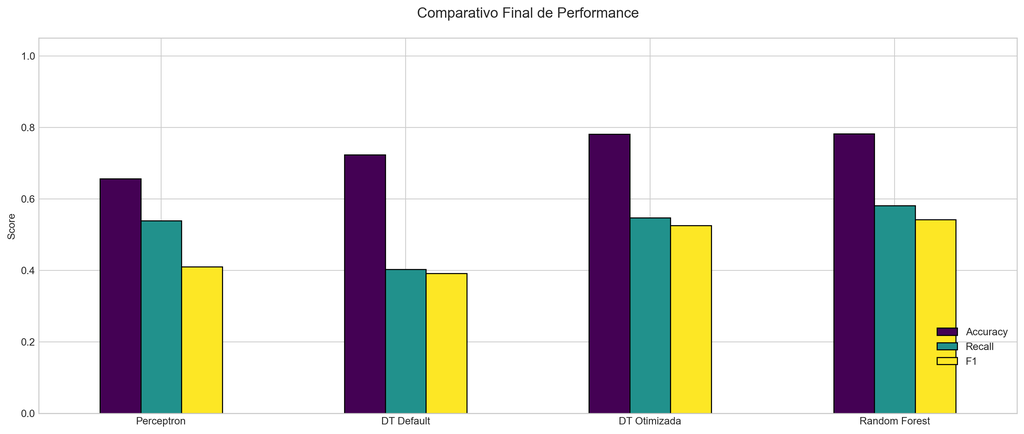

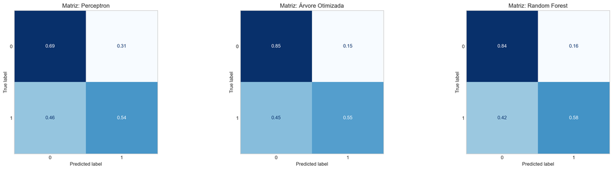

```python
# 1. Gráfico de Barras com as Métricas
df_res = pd.DataFrame(resultados_finais).T
print("Tabela Consolidada de Resultados:")
display(df_res)

df_res[['Accuracy', 'Recall', 'F1']].plot(kind='bar', figsize=(14, 6), colormap='viridis', edgecolor='black')
plt.title("Comparativo Final de Performance", pad=20, fontsize=14)
plt.ylabel("Score")
plt.ylim(0, 1.05)
plt.legend(loc='lower right', bbox_to_anchor=(1, 0.1))
plt.xticks(rotation=0)
plt.tight_layout()
plt.show()

# 2. Matrizes de Confusão (Onde a gente vê onde o modelo errou e acertou)
fig, axes = plt.subplots(1, 3, figsize=(20, 5))
model_list = [
    ('Perceptron', perc, X_test_scaled),
    ('Árvore Otimizada', best_dt, X_test),
    ('Random Forest', best_rf, X_test)
]

for i, (name, model, X_val) in enumerate(model_list):
    ConfusionMatrixDisplay.from_estimator(
        model, X_val, y_test, ax=axes[i], cmap='Blues', normalize='true', colorbar=False
    )
    axes[i].set_title(f"Matriz: {name}", fontsize=12)
    axes[i].grid(False)

plt.tight_layout()
plt.show()
```

### Conclusão: Qual modelo levar para a produção?

**2. A Dor do Bolso (Analisando as Matrizes de Confusão)** No mundo real do crédito, não basta olhar a "Acurácia". Precisamos focar nos erros.

- O **Falso Negativo** (cliente que o modelo diz que é bom, mas dá calote) é o erro que causa rombo no caixa do banco.
- O **Falso Positivo** (negar crédito a um bom cliente) faz o banco deixar de ganhar dinheiro. Como usamos `class_weight='balanced'` nas configurações, forçamos os nossos modelos de árvore a prestarem muita atenção nos caloteiros, melhorando significativamente a taxa de acerto (Recall) na classe de inadimplentes.

**3. O Trade-Off Final: Explicar vs. Lucrar** Qual modelo eu colocaria em produção amanhã? Depende do cenário corporativo:

- **Se a regra do jogo for compliance e clareza:** Se o Banco Central ou a área jurídica exigir que a gente consiga explicar o motivo exato de cada recusa de crédito para o consumidor, eu escolheria a **Árvore de Decisão Otimizada**. O custo de performance a menos vale a pena para ter um modelo transparente e auditável ("caixa-branca").
- **Se a regra do jogo for reduzir perdas e otimizar margem em larga escala:** Se o foco do projeto for puramente abater o risco financeiro global do portfólio, eu vou com o **Random Forest**. O custo de processamento a mais para treinar dezenas de árvores (custo computacional) é pífio se comparado ao dinheiro salvo por ele errar menos. Ele generaliza melhor, e o fato de ser uma "caixa-preta" é um trade-off que se paga em eficiência.